# RESULTS

Kelly Izzard

April 21, 2023

# 1 RESULTS

The Reporting Silviculture Updates and Land Status Tracking System (RESULTS) application tracks silviculture information by managing the submission of openings, disturbances, silviculture activities and obligation declarations as required by the Forest and Range Practices Act.

Under RESULTS, data is submitted using an Electronic Submission Framework (ESF) that is linked to associated spatial information, ensuring consistency in geographic information. All data (including spatial data) is replicated in the B.C. Geographic Data Warehouse.

The RESULTS database is pivotal for TSR as it provides the attributes that drives managed stand yield generation, is the primary source for data for assess practices and trends related to retention and harvest system selection and provides a spatial link between databases like ECAS/HBS through opening and timber mark.

This session will explore utilizing the RESULTS database to answer some typical TSR related questions.

## 1.1 Set up

The following code sets up our analysis and markdown document. These are the base packages I load for all my analysis

```r
#librarys
library(tidyverse)
library(bcdata)
library(sf)
library(terra)
library(DBI)
library(RPostgreSQL)
library(skimr)
library(knitr)
library(kableExtra)
library(scales)

#knitr...read about knitr here: https://sachsmc.github.io/knit-git-markr-guide/knitr/knit.html
knitr::opts_chunk$set(echo = TRUE)
knitr::opts_chunk$set(connection = "db")
knitr::opts_knit$set(sql.max.print = NA)
```

## 1.2 RESULTS Tables

### 1.2.1 Openings

RESULTS Openings are the administrative boundaries of areas harvested with silviculture obligations or areas of natural disturbances with intended(planned) forest management activities.

```r
# describe the opening variables, use the bcdc_search function to get the table id
op<-bcdc_describe_feature("53a17fec-e9ad-4ac0-95e6-f5106a97e677")%>%
       select(col_name,column_comments)

# create a pretty table using the updated kable function "kbl"
kbl(op) %>%
  kable_paper(full_width = F) %>%
  column_spec(1, bold = T, border_right = T) %>%
  column_spec(2, width = "50em", background = "yellow")
```

| col_name | column_comments |
| --- | --- |
| id | NA |
| OPENING_ID | The OPENING ID is a system generated value by RESULTS to uniquely identify the opening. |
| MAPSHEET_GRID | The MAPSHEET GRID refers to NTG or BCGS grid. Values are 82, 83, 92, 93, 94, 95, 102, 103,104, 114. |
| MAPSHEET_LETTER | The MAPSHEET LETTER is the NTG/BCGS letter. Values are A-P, and W. |
| MAPSHEET_SQUARE | The MAPSHEET SQUARE represents BCGS number values between 1-100 or NTG Number values 1-16. |
| MAPSHEET | The MAPSHEET is the full BCGS Mapsheet identifier. Eg. 92G100 |
| OPENING_NUMBER | The OPENING NUMBER is a unique four character field that is assigned to an opening on a specified mapsheet. |
| MAP_LABEL | The default label to be used when displaying the feature on a map. Consists of the MAPSHEET GRID, MAPSHEET LETTER, MAPSHEET SQUARE, and OPENING NUMBER. |
| OPENING_CATEGORY_CODE | The OPENING CATEGORY CODE indicates who holds the obligation and the extent and nature of the obligation. Eg. FTML - Forest Tenure Major Licensee; NDFS - Natural Disturbance Forest Service. |
| OPENING_STATUS_CODE | The OPENING STATUS CODE indicates whether the opening is or is not free growing based on all standards units being declared free growing. It also is used to tracked specific pending administrative and… |
| OPENING_LOCATION_NAME | The OPENING LOCATION NAME identifies the location name for the opening that is assigned by user. Eg. Peterson Creek. |
| DISTRICT_ADMIN_ZONE | The DISTRICT ADMIN ZONE represents different administrative zones within the district. These District Admin Zones are created and managed by MOF district staff to assist with district work events. |
| LICENSEE_OPENING_ID | The LICENSEE OPENING ID is a unique identifier provided by the Licensee to identify the Opening Number. |
| MAX_ALLOW_PERMNT_ACCESS_PCT | The MAX ALLOW PERMNT ACCESS PCT is the maximum allowable permanent access percent is the total maximum percentage of the gross area of the opening that can be occupied by permanent access structures. … |
| APPROVE_DATE | The APPROVAL DATE refers to the silviculture prescription approval date. For site plans, the approval date is auto-generated based on the first opening submission. |
| TSB_NUMBER_CODE | The TSB NUMBER CODE is the Timber Supply Block that is manually assigned to the opening. For any tenured openings reference can be made using the Management Unit Code and ID. |
| AMENDMENT_IND | The AMENDMENT IND indicates if there had been amendments made to the silviculture prescription or site plan on the opening. A value of ‘Y’ means there have been amendments. A value of ‘N’ means there … |
| PREV_TREE_SPECIES1_CODE | The PREV TREE SPECIES1 CODE identifies the dominant species of the stand before harvest from the previous forest cover inventory label of the largest polygon in the opening. |
| PREV_TREE_SPECIES2_CODE | The PREV TREE SPECIES2 CODE identifies the second species of the stand before harvest from the previous forest cover inventory label of the largest polygon in the opening. |
| PREV_STOCKING_STATUS_CODE | The PREV STOCKING STATUS CODE is obtained from the previous stand forest cover inventory label of the largest polygon in the opening. |
| PREV_AGE_CLASS_CODE | The PREV AGE CLASS CODE is obtained from the previous stand forest cover inventory label of the largest polygon in the opening. Age classes are intervals, or ranges, or ages into which trees, forest, … |
| PREV_HEIGHT_CLASS_CODE | The PREV HEIGHT CLASS CODE is obtained from the previous stand forest cover inventory label of the largest polygon in the opening. Height classes represents intervals into range of trees or stand heig… |
| PREV_SITE_INDEX | The PREV SITE INDEX is obtained from the leading species of the previous stand forest cover inventory label of the largest polygon in the opening. Estimates forest land productivity. |
| PREV_SITE_INDEX_SOURCE_CODE | The PREV SITE INDEX SOURCE CODE describes the source or origin of the previous site index obtained from the leading species of the previous stand forest cover inventory label of the largest polygon in… |
| RESULTS_SUBMISSION_ID | The RESULTS SUBMISSION ID is a system generated value generated by ESF to link between RESULTS opening data and the ESF submission. |
| REGION_CODE | The REGION CODE is the MOFR Region Code that the opening is located in. |
| REGION_NAME | The REGION NAME is the MOFR Region Name that the opening is located in. |
| DISTRICT_CODE | The DISTRICT CODE is the MOFR District Code that the opening is located in. |
| DISTRICT_NAME | The DISTRICT NAME is the MOFR District Name that the opening is located in. |
| BCTS_CODE | The BCTS CODE is the BC Timber Sales Organizational Code that the BCTS opening is located in. |

[output cut: 86 more lines]

### 1.2.2 Forest Cover

RESULTS opening’s forest cover poylgons with silviculture component provided. Current forest cover submission into RESULTS must contain attribute and map information. However, there are historical forest cover polygon infomration where maps are not available. Forest Cover is provided at three critical milestones of at **harvesting** (denudation), at **regeneration** (after regeneration delay), and at free growing. This is a part of the Silviculture and Land Status Tracking dataset, which includes tracking achievement of silviculture obligations on Crown Land.

The follow table lists the Forect Cover variables including a brief description of each brief description.

```r
## describe the fc variables
fc<-bcdc_describe_feature("258bb088-4113-47b1-b568-ce20bd64e3e3")%>%
       select(col_name,column_comments)

kbl(fc) %>%
  kable_paper(full_width = F) %>%
  column_spec(1, bold = T, border_right = T) %>%
  column_spec(2, width = "50em", background = "yellow")
```

| col_name | column_comments |
| --- | --- |
| id | NA |
| FOREST_COVER_ID | The FOREST COVER ID is a system-generated value by RESULTS to uniquely identify forest cover polygon. |
| STOCKING_STANDARD_UNIT_ID | The STOCKING STANDARD UNIT ID is a system-generated value by RESULTS to uniquely identify standards units. |
| OPENING_ID | The OPENING ID is a system generated value by RESULTS to uniquely identify the opening. |
| STANDARDS_UNIT_ID | The STANDARDS UNIT ID (SU) is an assigned unique identifier that represents the standards units. The SU that forest cover polygon is associated with. |
| SILV_POLYGON_NUMBER | The SILV POLYGON NUMBER is an assigned unique identifier that represents the forest cover polygon. |
| SILV_POLYGON_AREA | The SILV POLYGON AREA is the total area in hectares occupied by each polygon. The sum of all areas for a polygon(s) should not be greater than the opening gross area. |
| SILV_POLYGON_NET_AREA | The SILV POLYGON NET AREA is the area in hectares occupied by each polygon. The silviculture polygon net area is the silviculture polygon area minus the sum of all the associated non-mappable areas re… |
| SILV_NON_MAPPED_AREA | The SILV NON MAPPED AREA represents the sum of the total non-mappable area reported within each forest cover polygon. |
| STOCKING_STATUS_CODE | The STOCKING STATUS CODE is an indication of growing space occupancy relative to establish standard. Status refers to whether the site has met those standards. Stocking status is most often described … |
| STOCKING_TYPE_CODE | The STOCKING TYPE CODE is a further classification of stocking status for the polygon. Eg. NAT-natural, PL-planting, etc. |
| STOCKING_CLASS_CODE | The STOCKING CLASS CODE represents a numeric code representing a range of stems per hectares. Examples: stocking class 0 is immature; stocking class 1 is mature with 76+ stems/ha > 27.5dbh. |
| SILV_RESERVE_CODE | The SILV RESERVE CODE identifies the spatial pattern of a reserve of retention area associated with a silvicultural system. Reserves are forest patches or individual trees retained during harvesting, … |
| SILV_RESERVE_OBJECTIVE_CODE | The SILV RESERVE OBJECTIVE CODE refers to the management goal of the reserve. Examples: WTR-Wildlife Tree Retention; RMA-Riparian reserve, etc. |
| TREE_COVER_PATTERN_CODE | The TREE COVER PATTERN CODE is the spatial arrangement of residual patches of overstorey (Layer 1). Applies to polygons in which trees are retained as apart of the silvicultural system or disturbance … |
| REENTRY_YEAR | The RE-ENTRY YEAR is the year the next harvest entry is expected to occur in the opening. Applies to partial-cut silvicultural systems. This field is optional. |
| REFERENCE_YEAR | REFERENCE YEAR is the year the forest cover polygon data were collected. |
| SITE_INDEX | The SITE INDEX is a measure of forest land productivity. Enter the projected average height in metres of the leading species of the forest cover silviculture at 50 years after the stands achieves brea… |
| SITE_INDEX_SOURCE_CODE | The SITE INDEX SOURCE CODE is a source or origin of the site index. Example: C-site index from site index curve. |
| BGC_ZONE_CODE | The BGC ZONE CODE of the SU, according to the Biogeoclimatic Ecosystem Classification (BEC) system. Eg. IDF; MS; CWH. |
| BGC_SUBZONE_CODE | The BGC SUBZONE CODE of the SU, according to the BEC system. Eg. dk; xc; mk. |
| BGC_VARIANT | The BGC VARIANT according to the BEC system. Eg. 1, 2. A division of the BGC Subzone on the basis of differences in floristic composition of the zonal ecosystem, but usually on the basis of difference… |
| BGC_PHASE | The BGC PHASE according to the BEC system. Accommodates the variation, resulting from local relief, in the regional climate of the subzones and variants. |
| BEC_SITE_SERIES | Site series for the given biogeoclimatic unit, according to the BEC system. Eg. 01, 04, 05. Site series is the consideration of all ecosystems capable of producing vegetation belonging to the same pla… |
| BEC_SITE_TYPE | The BEC SITE TYPE for certain site series, according to the BEC system. Site type is the partitionment of the site series according to one or more critical site factors thought to affect ecosystem res… |
| BEC_SERAL | The BEC SERAL is the seral (often termed successional) classification in BEC is an integration of site and vegetation classifications with structural stage development |
| IS_SILV_IMPLIED_IND | The IS SILV IMPLIED is the information copied from silviculture component for silviculture component when no separate silviculture information is provided. No significant difference in densities and s… |
| FOREST_COVER_SILV_TYPE | The FOREST COVER SILV TYPE describes the forest cover stand type characteristics: EVEN, UNEVEN, NONE and UNKNOWN. |
| S_FOREST_COVER_LAYER_ID | The S FOREST COVER LAYER ID is a RESULTS system-generated unique identifier for the layer information. |
| S_TOTAL_STEMS_PER_HA | The S TOTAL STEMS PER HA is the total stems per hectare for the “even-aged” forest cover polygon. |

[output cut: 130 more lines]

**Forest Cover is submitted before June 1 for areas where:**

- Where harvesting has been completed before March 31 of that year
- Has met regeneration date up to March 31 of that year (the first survey which can take up to 7 years depending on FSP commitments)
- Has not met regeneration requirements but the regeneration date has passed prior to March 31 of that year
- Has met free growing date requirements up to March 31 of that year and to fulfil THSPR obligation (which can take up to 15 - 20 years depending on FSP commitments)
- Free growing declaration has been made in accordance to FRPA 107 and FPPR 97; or,(the last survey which can take up to 15 - 20 years depending on FSP commitments)
- Has not met free growing requirements but the free growing date has passed prior to March 31 of that year

## 1.3 NSR and RESULTS

Recently we received an email inquiring about the Boundary (TSA02) TSR that asked:

*“What is the extent of the NSR areas? There are many of these present in the Boundary and they have significantly increased since the last analysis and continue to grow. This is especially true across the IDF biogeoclimatic zone.”*

Government formalized the definition of **not satisfactorily restocked** (NSR) because of amendments to the Forest Act, made in 1987, that changed the requirements to restock (or reforest) areas that have been harvested. Stands harvested after October 1, 1987 (enactment of Bill 70), generate a legal free growing obligation which is defined as being met when the stand achieves specified parameters. The meeting of those parameters has to be able to be independently verified by the MFR, therefore the rigour in which the information is collected has always been high. Free growing surveys for the achievement of legal obligations did not start on mass until approximately 1995 because some of the more productive stands harvested in 1988 would just then start to be of sufficient condition to be declared as free growing. It wasn’t till about 2002 (i.e. 15 years after the start of Bill 70) when the steady state level of free growing surveys was achieved and that level remains to this day.

The current definition of an NSR area is: **an area not covered by a sufficient number of well-spaced trees of desirable species**. A **stocking standard** provides precise definitions of the words **sufficient**, **well-spaced** and **desirable**. The “area” referred to can be **NSR** for any reason (i.e., logging or natural disturbance) but the stocking standards were originally developed for use in the context of a logged cutblock.

From an administrative perspective an area can only be **NSR** if:

1. the area has been surveyed and the results have been compared to a stocking standard; and
2. industry has a legal obligation to restock the area or government has determined that the area is feasible to restock (based primarily on return on investment criteria).

There are a minimum of three survey points in the life of an opening:

1. Upon denudation
2. At Regeneration Delay
3. At Free-Growing

Upon denudation an opening is automatically classified as **NSR** in the Forest Cover **Stocking Status Code** and that status is updated upon subsequent surveys. It possible that the next survey point (Regen Delay) may not occur for several years (potentially a maximum of 7) and therefore the initial “NSR” designation may persist in the database for a significant period. It’s also possible for an individual standard unit to be **NSR** while the opening as a whole is classified as **free growing** depending on the approved standards in a given FSP. As such the notion of **NSR** is very specific and has limited utility when discussing inventory or timber supply.

So lets use RESULTS to assess the claim that **NSR** significantly increased since the last analysis and continue to grow in the Boundary TSA.

## 1.4 Get Boundary

The first step is to get our unit of interest out of the BCDW. We’ll use it to extract both the opening and forest cover data. We’ll also dissolve the SF object on TSA number, eliminating the supply block linework and simplifying future intersections with the forst cover and opening datasets.

```r
tsa02<- bcdc_query_geodata("8daa29da-d7f4-401c-83ae-d962e3a28980") %>%
  filter(TSA_NUMBER_DESCRIPTION =="Boundary TSA") %>% # filter for Boundary TSA
  collect()%>%
  group_by(TSA_NUMBER_DESCRIPTION)%>%
  summarise()
```

## 1.5 Get the forest cover

Next we want to extract the forest cover attribution for the unit. We only want a select set of attributions related to stocking status so we’ll limit our select to the first 25 fields

```r
#extract by bounding box
tsa02_fc<-bcdc_query_geodata("258bb088-4113-47b1-b568-ce20bd64e3e3") %>%
  filter(INTERSECTS(tsa02))%>%
  select(1:25)%>%
  collect()

# extract by unit boundary and drop the geometry
tsa02_fc_clip <- st_intersection(tsa02_fc, tsa02)

tsa02_fc_clip  <- tsa02_fc_clip %>% st_drop_geometry()

#summarise NSR by year of survey
tsa02_fc_clip%>%
  filter(STOCKING_STATUS_CODE == "NSR" & BGC_ZONE_CODE == "IDF")%>%
  group_by(REFERENCE_YEAR,BGC_ZONE_CODE,STOCKING_STATUS_CODE)%>%
  summarise(area = sum(SILV_POLYGON_NET_AREA))%>%
  arrange(desc(REFERENCE_YEAR))
```

| REFERENCE_YEAR | BGC_ZONE_CODE | STOCKING_STATUS_CODE | area |
| --- | --- | --- | --- |
| 2022 | IDF | NSR | 700.0 |
| 2021 | IDF | NSR | 427.3 |
| 2020 | IDF | NSR | 284.0 |
| 2019 | IDF | NSR | 78.2 |
| 2018 | IDF | NSR | 116.7 |
| 2017 | IDF | NSR | 364.8 |
| 2016 | IDF | NSR | 226.6 |
| 2015 | IDF | NSR | 51.9 |
| 2014 | IDF | NSR | 142.8 |
| 2013 | IDF | NSR | 143.9 |

[output cut: 6 more lines]

A cursory glance suggest there is some NSR which requires further investigation.

## 1.6 Get the openings and query the data

To take a deeper dive we’ll need the opening status and denudation dates from the Openings dataset. We’ll join the two dataframes. We’ll use the [lubridate](https://lubridate.tidyverse.org/) package to first extract the denudation end year then we’ll create a fiscal year variable (Since RESULTS reporting is based on fiscal year we need to re-organize the data for consistency with the reporting obligations).

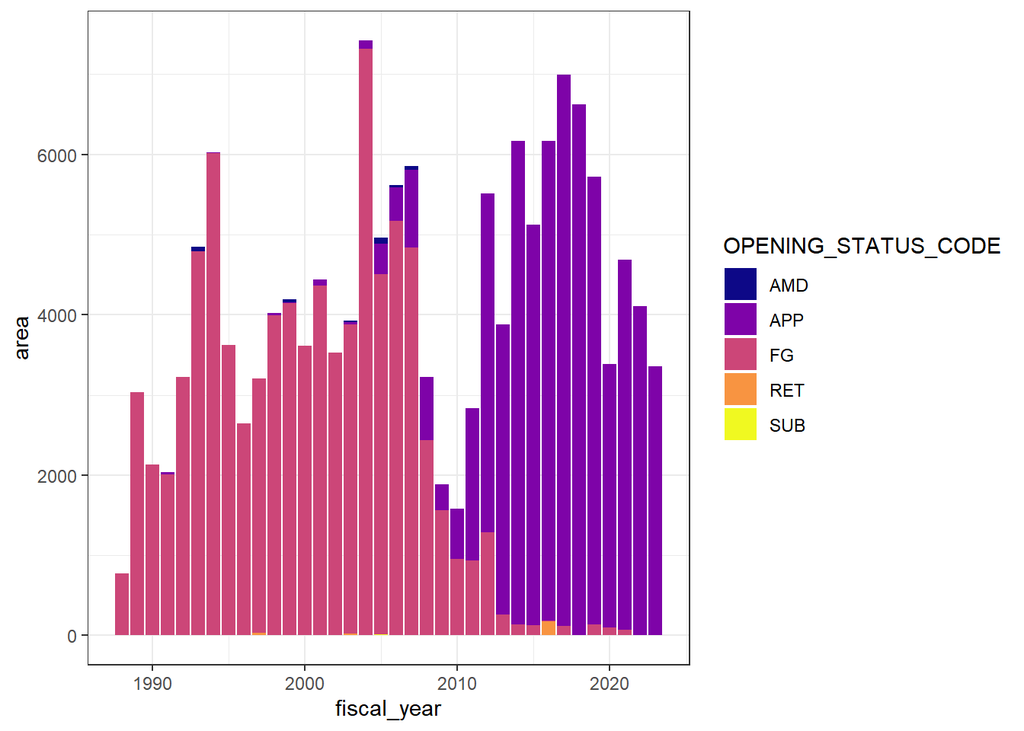

```r
tsa02_openings<-bcdc_query_geodata("53a17fec-e9ad-4ac0-95e6-f5106a97e677") %>%
  filter(INTERSECTS(tsa02))%>%
  collect()%>%
  select(OPENING_ID,
         OPENING_STATUS_CODE,
         DISTURBANCE_START_DATE,
         DISTURBANCE_END_DATE,
         DENUDATION_1_SILV_SYSTEM_CODE,
         FEATURE_AREA)%>%
  st_drop_geometry()

library(lubridate)

tsa02_openings<-tsa02_openings%>%
  mutate(start_year = year(DISTURBANCE_START_DATE),
         end_year = year(DISTURBANCE_END_DATE),
         harv_duration = case_when(
           end_year > start_year~end_year-start_year,
           TRUE ~ -99))

tsa_silvi<-inner_join(tsa02_openings,
                     tsa02_fc_clip,
                     by = "OPENING_ID",
                     multiple = "all")%>%
  mutate(fiscal_year = ifelse(month(DISTURBANCE_END_DATE)>3, year(DISTURBANCE_END_DATE)+1, year(DISTURBANCE_END_DATE)))


#create a status variable that combines opening status and stocking status
post87<-tsa_silvi%>%
  filter(end_year > 1987)%>%
  mutate(status =paste(OPENING_STATUS_CODE,
                       STOCKING_STATUS_CODE,
                       sep = "_"),
    status = fct_lump(status, prop = .01))

# plot the opening status
post87%>%
   group_by(fiscal_year,OPENING_ID,OPENING_STATUS_CODE)%>%
   summarise(area = mean(FEATURE_AREA))%>%
   ggplot(aes(fill = OPENING_STATUS_CODE, x=fiscal_year,y = area))+
   geom_bar(position="stack", stat="identity")+
   scale_fill_viridis_d(option = "plasma")+
   theme_bw()
```

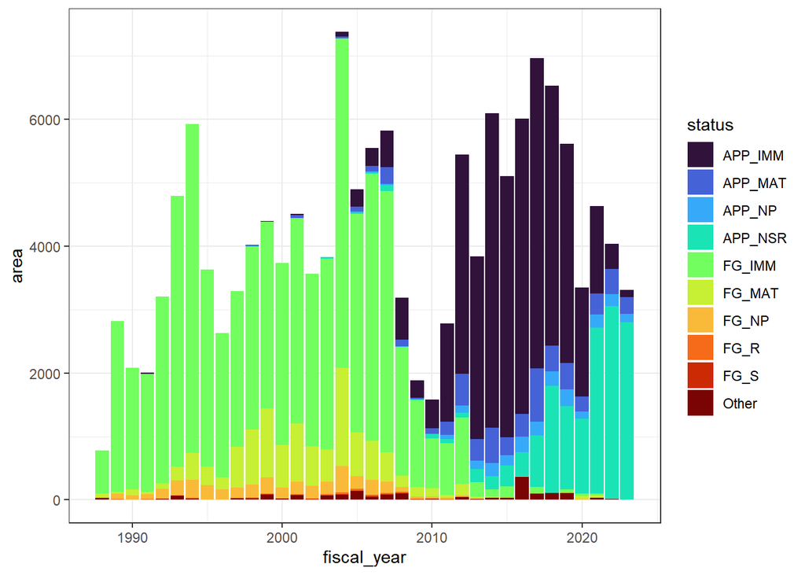

```r
#plot the stocking status by opening status
post87%>%
   group_by(fiscal_year ,status)%>%
   summarise(area = sum(SILV_POLYGON_NET_AREA))%>%
   ggplot(aes(fill=status,x=fiscal_year ,y = area))+
   geom_bar(position="stack", stat="identity")+
   scale_fill_viridis_d(option = "turbo")+
   theme_bw()
```

```r
#lets look at the Other where stocking status  = "NSR"
(Other<-post87%>%filter(status == "Other"&
                  STOCKING_STATUS_CODE== "NSR")%>%
  group_by(STOCKING_STATUS_CODE,fiscal_year)%>%
  summarise(area = sum(SILV_POLYGON_NET_AREA))%>%
  arrange(desc(fiscal_year)))
```

| STOCKING_STATUS_CODE | fiscal_year | area |
| --- | --- | --- |
| NSR | 2019 | 79.5 |
| NSR | 2016 | 86.9 |
| NSR | 2008 | 96.7 |
| NSR | 2007 | 53.1 |
| NSR | 2005 | 28.7 |
| NSR | 2004 | 63.6 |
| NSR | 2003 | 8.9 |
| NSR | 2002 | 3.0 |
| NSR | 2001 | 14.3 |
| NSR | 2000 | 2.9 |

[output cut: 2 more lines]

```r
#what is the total Other NSR
Other%>%summarise(Other_NSR = sum(area))
```

| STOCKING_STATUS_CODE | Other_NSR |
| --- | --- |
| NSR | 479.6 |

As we can see the vast majority of standard units classified as “NSR” are recently harvested openings that are likely in the lag period between denudation and regeneration delay surveys. Very few early standard units are classified as NSR. Therefore concerns related to growing trends in NSR (outstanding stocking obligations) appear unwarranted (or at least not supported by the data). This is not to suggest that there aren’t significant regeneration issues associated with the IDF (dry belt fir zone) in the Boundary TSA. A recent special investigation by the Forest Practices Board (FPB) found:

*“The [investigation](https://www.bcfpb.ca/wp-content/uploads/2020/09/SIR53-Reforestation-in-IDF-Subzone.pdf) concludes that licensees complied with FRPA reforestation requirements but are not implementing the best management practices that would maintain an expected mix of tree species on dry belt fir stands, potentially affecting mid-term timber supply expectations and forest cover requirements for non-timber resources. FLNRORD initiatives are intended to address the challenges faced by licensees and, with timely development and implementation, should serve to help improve reforestation practices in dry-belt fir stands in the short term. However, given the expected impacts of climate change, the Board is concerned about what this means for future timber supply and other forest values.”*

The FPB [website](https://www.bcfpb.ca/) is also a rich source of information and data and should be explored regularly for unit specific issues that could have a bearing on TSR.

## 1.7 Retention and RESULTS

Stand level retention refers to unharvested areas associated with individual cutblocks. RESULTS is an important data source for assessing retention practices in a unit.

There are two types of reserves identified in RESULTS:

**Long term residuals or reserves** – stands retained for an entire rotational planning cycle. “Reserves” are understood to not be available for harvesting until next rotational cycle of the stand

**Short term residuals or retention** - stands are retained (whether or not they are eventually harvested in another entry) for a portion of a current planning cycle.

Retention is further categorised as:

**“G” - Group Reserves**: a defined, mapped patch of trees, generally does not have NAR.

Group Reserves:

- do not have harvest entries or silviculture responsibilities, and are mapped and reported
- reserve polygons with inventory component, if supplied, are used to update VRI
- no silviculture component is required
- areas are often reported as even-aged with residual stems comprising the entire reserves

**“D” - Dispersed**: trees that are retained individually or in unmapped groups (small clusters <0.25ha), but are enclosed within the boundaries of the mapped polygon designated as “dispersed reserves” and is within a net area to be reforested (NAR).

Dispersed Reserves:

- have harvesting and is associated with an SU within which the denuded and residual treed portions are not individually mapped
- boundary of entire polygon is mapped, and the denuded and residual portions of the polygon are described in the inventory and silviculture components
- reported as multi-layer stands where dispersed retention is >5m2 per ha* of residual basal area associated with a SU. Minimum two layers are reported: the denuded layer and the layer containing the residual stems

In addition to the retention type category the reserves are also classified by their objective. The **Reserve Objective Code** refers to the management goal of the retained trees. RESULTS has only one Reserve Objective Code option for entry even though reserves may serve multiple objectives.

Objectives include:

**TIM** (Timber Management) residuals that are considered to short term retention and available for subsequent harvest entry prior to the end of the current rotation planning cycle (whether they are actually harvested or not). A TIM classification requires a re-entry year be identified in RESULTRS. Any reserve objective code other than “TIM” is considered long term retention and not available for subsequent harvest entry until after the next rotational planning cycle.

**Reserves** constrained for entire rotation, use primary constraining objective (ie. WTR, RMA or any code other than TIM). This will be used for calculation for WTR percentages (FPPR s.66).

**There are serious data quality issues associated with early entries related to retention in the RESULT database that have yet to be corrected. As a consequence data samples should be restricted to the last 10 year to ensure an unbiased assessment. Experience suggests further trimming at the 1 and 99 percentiles are also warranted.**

Lets assess the average retention in the Boundary TSA over the past decade.

```r
## create a retention dataframe
tsa02_ret<-tsa_silvi%>%filter(start_year > 2012 &
                   !is.na(SILV_RESERVE_CODE))%>%
   select( OPENING_ID,
           SILV_RESERVE_CODE,
           SILV_RESERVE_OBJECTIVE_CODE,
           SILV_POLYGON_NET_AREA,
           FEATURE_AREA)
#generate a quick summary
  tsa02_ret%>%
   group_by(SILV_RESERVE_CODE,SILV_RESERVE_OBJECTIVE_CODE)%>%
   summarise(area = sum(SILV_POLYGON_NET_AREA))
```

| SILV_RESERVE_CODE | SILV_RESERVE_OBJECTIVE_CODE | area |
| --- | --- | --- |
| D | BIO | 209.3 |
| D | OTH | 2118.3 |
| D | TIM | 3537.9 |
| D | WTR | 2709.2 |
| G | BIO | 713.0 |
| G | OTH | 252.8 |
| G | RMA | 6.1 |
| G | SEN | 0.7 |
| G | TIM | 483.3 |
| G | WTR | 3284.6 |

[output cut: 2 more lines]

```r
# isolate the grouped retention that doesn't have a timber objective
tsa02_ret<-tsa02_ret%>%
    filter(SILV_RESERVE_CODE == "G" &
             SILV_RESERVE_OBJECTIVE_CODE != "TIM")%>%
    group_by(OPENING_ID)%>%
  summarise(retention = sum(SILV_POLYGON_NET_AREA),
            blk_area = mean(FEATURE_AREA),
            prop = retention/blk_area)
# find the upper an lower bounds for data cleaning
 quantile(tsa02_ret$prop,probs = seq(0,.1,0.01))#0.03236258
```

```
##         0%         1%         2%         3%         4%         5%         6%
## 0.01119359 0.03251516 0.03727108 0.03900843 0.04231084 0.04423965 0.04688106
##         7%         8%         9%        10%
## 0.04943167 0.05127588 0.05311044 0.05520427
```

```r
 quantile(tsa02_ret$prop,probs = seq(.9,1,0.01))#0.2697692
```

```
##       90%       91%       92%       93%       94%       95%       96%       97%
## 0.1536398 0.1589893 0.1634359 0.1695273 0.1794212 0.1877818 0.2051819 0.2185134
##       98%       99%      100%
## 0.2431136 0.2692979 0.9834153
```

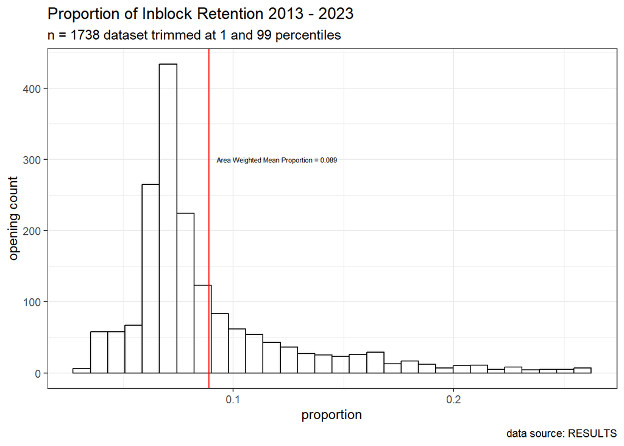

```r
#filter the dataframe by upper and lower bounds to create trimmed df
 tsa02_ret<-tsa02_ret%>%
   filter(between(prop,0.032,0.26))

 #calculate athe area weighed proportion
 x<-weighted.mean(tsa02_ret$prop,tsa02_ret$blk_area)

 #visualize
 tsa02_ret%>%
   ggplot(aes(prop))+
   geom_histogram(color = "black",
                  fill = "transparent")+
   geom_vline(xintercept = x,col = "red")+
   annotate("text", x = 0.12, y = 300,
            label = "Area Weighted Mean Proportion = 0.089",
            size = 2)+
   labs(title = "Proportion of Inblock Retention 2013 - 2023",
        subtitle = "n = 1738 dataset trimmed at 1 and 99 percentiles",
        caption = "data source: RESULTS",
        x = "proportion",
        y = "opening count")+
   theme_bw()
```

The area weight mean retention level in Boundary is 8.9%. I will use this value in my Boundary netdown as an aspatial exclusion factor applied across the THLB.

That’s a wrap